# Flights_Explainatory_Presentation slides

### Flight - Can We Really Explain Them

#### Investigation Overview

> This dataset is from Bureau of Transportation Statistics. It tracks the on time performance of domestic flights operated by large air carriers. The dataset is for each year and can be downloaded directly from their website. The description is posted on their website in detail.

#### Dataset Overview

> For this data analysis, we will be looking at data from the years 2007 and 2008.

##### At first Glance this is how our raw data looks like

|  | Year | Month | DayofMonth | DayOfWeek | DepTime | CRSDepTime | ArrTime | CRSArrTime | UniqueCarrier | FlightNum | ... | TaxiIn | TaxiOut | Cancelled | CancellationCode | Diverted | CarrierDelay | WeatherDelay | NASDelay | SecurityDelay | LateAircraftDelay |
| --- | --- | --- | --- | --- | --- | --- | --- | --- | --- | --- | --- | --- | --- | --- | --- | --- | --- | --- | --- | --- | --- |
| 874467 | 2007 | 2 | 7 | 3 | 1922.0 | 1850 | 2105.0 | 2027 | US | 924 | ... | 7.0 | 19.0 | 0 | NaN | 0 | 17.0 | 0.0 | 6.0 | 0.0 | 15.0 |
| 1680305 | 2008 | 3 | 13 | 4 | 1900.0 | 1900 | 2119.0 | 2105 | AA | 1093 | ... | 6.0 | 24.0 | 0 | NaN | 0 | NaN | NaN | NaN | NaN | NaN |
| 145753 | 2007 | 1 | 21 | 7 | NaN | 901 | NaN | 1005 | YV | 7047 | ... | 0.0 | 0.0 | 1 | B | 0 | 0.0 | 0.0 | 0.0 | 0.0 | 0.0 |
| 6681532 | 2007 | 11 | 12 | 1 | 1633.0 | 1629 | 1809.0 | 1759 | NW | 1421 | ... | 12.0 | 13.0 | 0 | NaN | 0 | 0.0 | 0.0 | 0.0 | 0.0 | 0.0 |
| 382482 | 2007 | 1 | 26 | 5 | 1603.0 | 1605 | 1652.0 | 1656 | HA | 262 | ... | 5.0 | 10.0 | 0 | NaN | 0 | 0.0 | 0.0 | 0.0 | 0.0 | 0.0 |
| 3840129 | 2007 | 7 | 2 | 1 | 815.0 | 825 | 1107.0 | 1112 | YV | 7203 | ... | 8.0 | 16.0 | 0 | NaN | 0 | 0.0 | 0.0 | 0.0 | 0.0 | 0.0 |
| 586450 | 2007 | 1 | 31 | 3 | 829.0 | 830 | 1155.0 | 1150 | CO | 801 | ... | 4.0 | 56.0 | 0 | NaN | 0 | 0.0 | 0.0 | 0.0 | 0.0 | 0.0 |
| 3683340 | 2007 | 6 | 3 | 7 | 1633.0 | 1630 | 1732.0 | 1740 | DL | 1927 | ... | 4.0 | 13.0 | 0 | NaN | 0 | 0.0 | 0.0 | 0.0 | 0.0 | 0.0 |
| 3823677 | 2007 | 7 | 19 | 4 | 705.0 | 710 | 823.0 | 838 | XE | 3059 | ... | 7.0 | 10.0 | 0 | NaN | 0 | 0.0 | 0.0 | 0.0 | 0.0 | 0.0 |
| 6683792 | 2007 | 11 | 20 | 2 | 1844.0 | 1849 | 1959.0 | 2018 | NW | 1536 | ... | 9.0 | 10.0 | 0 | NaN | 0 | 0.0 | 0.0 | 0.0 | 0.0 | 0.0 |
| 285128 | 2007 | 1 | 7 | 7 | 755.0 | 800 | 1023.0 | 1021 | US | 979 | ... | 7.0 | 26.0 | 0 | NaN | 0 | 0.0 | 0.0 | 0.0 | 0.0 | 0.0 |
| 5655212 | 2007 | 10 | 18 | 4 | 1048.0 | 1040 | 1152.0 | 1150 | WN | 662 | ... | 3.0 | 7.0 | 0 | NaN | 0 | 0.0 | 0.0 | 0.0 | 0.0 | 0.0 |
| 1647183 | 2008 | 3 | 14 | 5 | 1843.0 | 1845 | 2026.0 | 2055 | 9E | 4793 | ... | 12.0 | 11.0 | 0 | NaN | 0 | NaN | NaN | NaN | NaN | NaN |
| 3921018 | 2007 | 7 | 21 | 6 | 1126.0 | 1130 | 1220.0 | 1228 | OO | 3739 | ... | 4.0 | 10.0 | 0 | NaN | 0 | 0.0 | 0.0 | 0.0 | 0.0 | 0.0 |
| 3219532 | 2007 | 6 | 18 | 1 | 900.0 | 910 | 1027.0 | 1030 | YV | 2722 | ... | 6.0 | 13.0 | 0 | NaN | 0 | 0.0 | 0.0 | 0.0 | 0.0 | 0.0 |
| 5821653 | 2007 | 10 | 25 | 4 | 903.0 | 850 | 1218.0 | 1200 | OO | 2525 | ... | 10.0 | 12.0 | 0 | NaN | 0 | 18.0 | 0.0 | 0.0 | 0.0 | 0.0 |
| 6934283 | 2007 | 12 | 12 | 3 | 1450.0 | 1500 | 1657.0 | 1705 | XE | 54 | ... | 7.0 | 12.0 | 0 | NaN | 0 | 0.0 | 0.0 | 0.0 | 0.0 | 0.0 |
| 328166 | 2007 | 1 | 31 | 3 | 1533.0 | 1540 | 1746.0 | 1806 | DL | 1624 | ... | 11.0 | 8.0 | 0 | NaN | 0 | 0.0 | 0.0 | 0.0 | 0.0 | 0.0 |
| 7238629 | 2007 | 12 | 25 | 2 | NaN | 1645 | NaN | 1810 | MQ | 3555 | ... | 0.0 | 0.0 | 1 | A | 0 | 0.0 | 0.0 | 0.0 | 0.0 | 0.0 |
| 4811930 | 2007 | 8 | 13 | 1 | 1201.0 | 1204 | 1352.0 | 1346 | NW | 327 | ... | 15.0 | 26.0 | 0 | NaN | 0 | 0.0 | 0.0 | 0.0 | 0.0 | 0.0 |
| 1223205 | 2007 | 3 | 12 | 1 | 2039.0 | 2040 | 2154.0 | 2155 | WN | 678 | ... | 5.0 | 11.0 | 0 | NaN | 0 | 0.0 | 0.0 | 0.0 | 0.0 | 0.0 |
| 980881 | 2007 | 2 | 13 | 2 | 1117.0 | 1110 | 1231.0 | 1225 | MQ | 3381 | ... | 3.0 | 17.0 | 0 | NaN | 0 | 0.0 | 0.0 | 0.0 | 0.0 | 0.0 |
| 2492007 | 2007 | 5 | 18 | 5 | 1225.0 | 1225 | 1417.0 | 1425 | WN | 461 | ... | 5.0 | 7.0 | 0 | NaN | 0 | 0.0 | 0.0 | 0.0 | 0.0 | 0.0 |
| 5112350 | 2007 | 9 | 7 | 5 | 1230.0 | 1225 | 1333.0 | 1338 | XE | 429 | ... | 4.0 | 8.0 | 0 | NaN | 0 | 0.0 | 0.0 | 0.0 | 0.0 | 0.0 |
| 2274354 | 2008 | 4 | 14 | 1 | 1640.0 | 1645 | 1831.0 | 1845 | AA | 677 | ... | 6.0 | 16.0 | 0 | NaN | 0 | NaN | NaN | NaN | NaN | NaN |
| 808579 | 2008 | 2 | 28 | 4 | 536.0 | 545 | 647.0 | 712 | OO | 6330 | ... | 3.0 | 11.0 | 0 | NaN | 0 | NaN | NaN | NaN | NaN | NaN |
| 1437257 | 2008 | 3 | 1 | 6 | 1024.0 | 1030 | 1401.0 | 1411 | US | 274 | ... | 7.0 | 21.0 | 0 | NaN | 0 | NaN | NaN | NaN | NaN | NaN |
| 7306047 | 2007 | 12 | 10 | 1 | 1930.0 | 1905 | 2036.0 | 2010 | 9E | 2803 | ... | 9.0 | 21.0 | 0 | NaN | 0 | 0.0 | 0.0 | 1.0 | 0.0 | 25.0 |
| 5374111 | 2007 | 9 | 5 | 3 | 850.0 | 905 | 1055.0 | 1115 | HA | 43 | ... | 4.0 | 9.0 | 0 | NaN | 0 | 0.0 | 0.0 | 0.0 | 0.0 | 0.0 |
| 3967831 | 2007 | 7 | 10 | 2 | 1119.0 | 1045 | 1227.0 | 1206 | UA | 857 | ... | 3.0 | 18.0 | 0 | NaN | 0 | 0.0 | 0.0 | 21.0 | 0.0 | 0.0 |

30 rows × 29 columns

### Airline-wise cancellations

> In as much as there a canclellation, the analysis really doesnt show a lot of flight cancellation overtime. The cancellation are wise in the sense that they are due to serious condtions such as weather, security and carrier technical problems

> From the Bar on the next slide, we can see that 2007 had the most flights cancelled. But I am interested to know the cancellation causes.

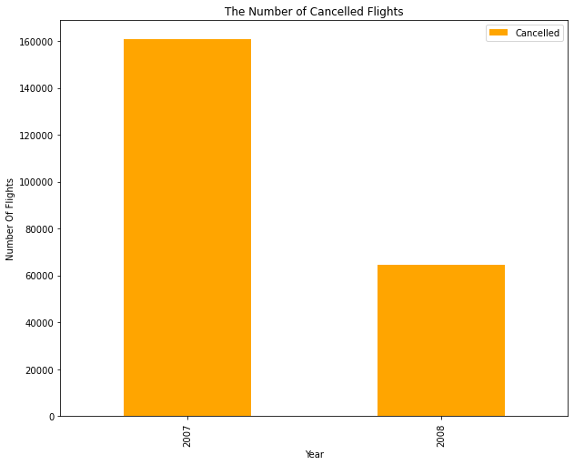

#### Below is a chart that looks at the proportion of Cancelled flights

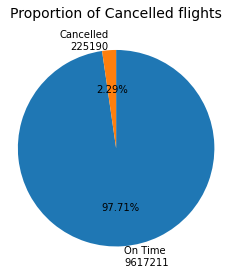

#### As mentioned in the previous slide

> The next slide gives us a glance of what we could call the major causes of the flight cancellation

> > It is evident from the graph above that "A" (Carrier) and "B" (Weather) account for the majority of flight cancellations. But "D" (security) is the least contributing to the cancellation. We have 92854 cancellation from Carrier and 87680 extreme weather. I am also interested to see which month had the most cancellations.

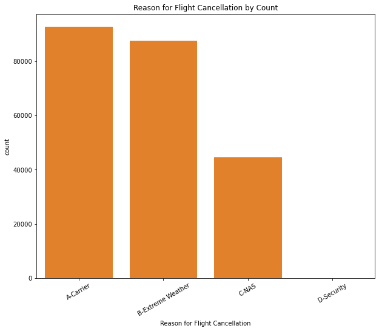

```
A    92854
B    87680
C    44612
D       45
Name: CancellationCode, dtype: int64
```

[figure not shown]

#### Overal Distribution Delays.

> Passengers should be aware that airlines do not guarantee their timetables when making travel arrangements. Although airlines strive to deliver passengers to their destinations on time, a number of factors can and occasionally do delay flights. Some challenges, such as inclement weather, air traffic delays, and technical problems, are difficult to anticipate and frequently out of the airlines' control.

> > The chats below shows delay distributions

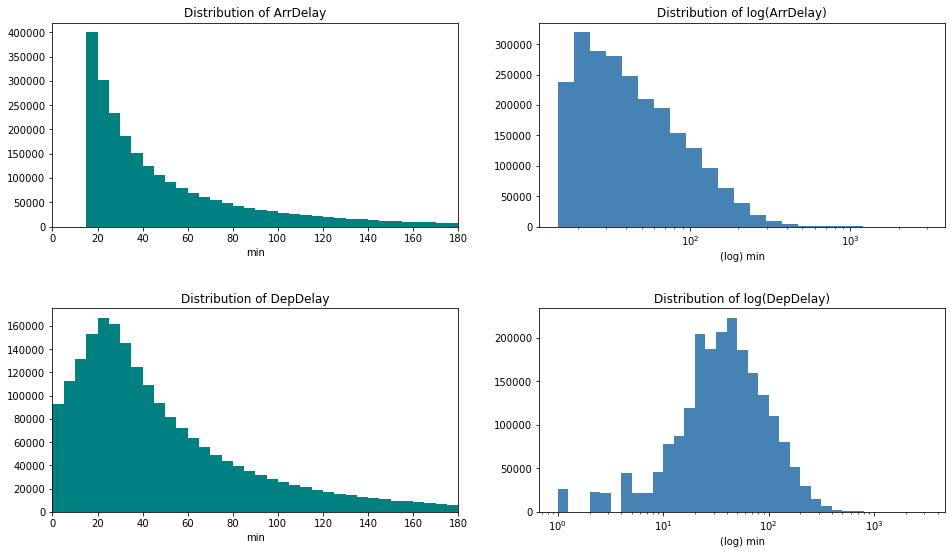

#### Lets talk about cancellation by month.

> According to the Bureau of Transportation Statistics of the Transportation Department, more over a quarter of commercial flights in the United States in January arrived late, were canceled, or were diverted, a modest increase from the same month in 2016. The outcomes were an improvement from December, a month that is typically busy for leisure travelers, when the 20 top airlines in the country experienced flight delays, cancellations, or diversions on over 36% of their flights.

> > The plot above for "B" demonstrates that the greatest cancellations occurred in the months of December, January, February, and March. Since "B" is cancellations due to weather, this may be the case, but we'll look at other scenarios later.

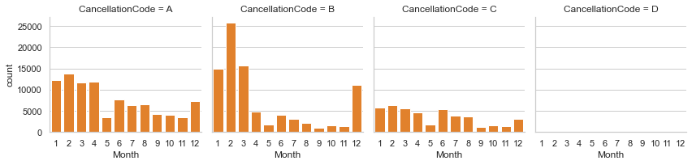

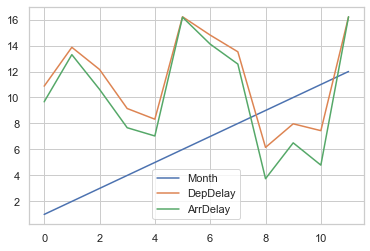

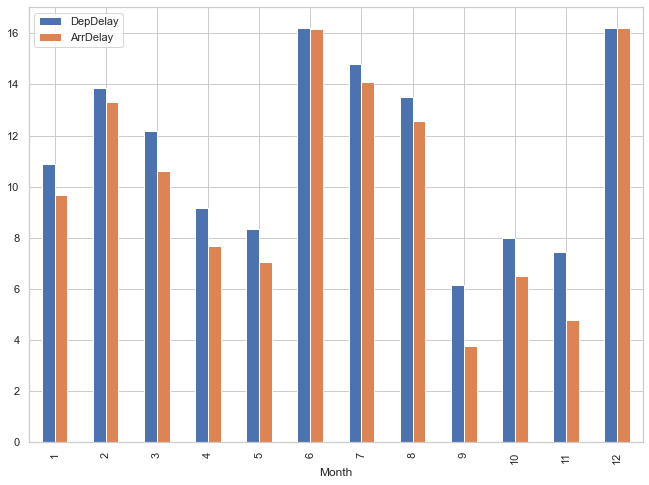

##### Flights to destinations have an effect on arrival delays?

> Only in 2000, when more than 27% of flights were delayed or canceled, did travelers have more trouble arriving at their destinations on time. In 2007, when carriers ran approximately 7.5 million one-way trips, there were 31% fewer flights back then.

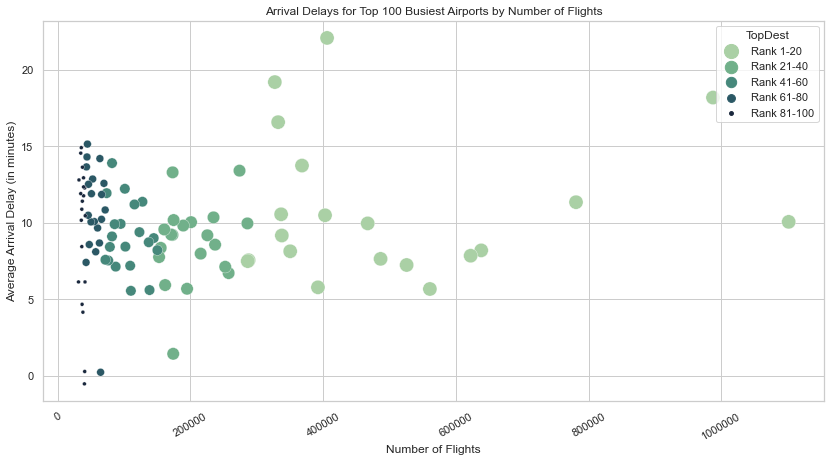

##### Finding the relation between delays and their Reasons

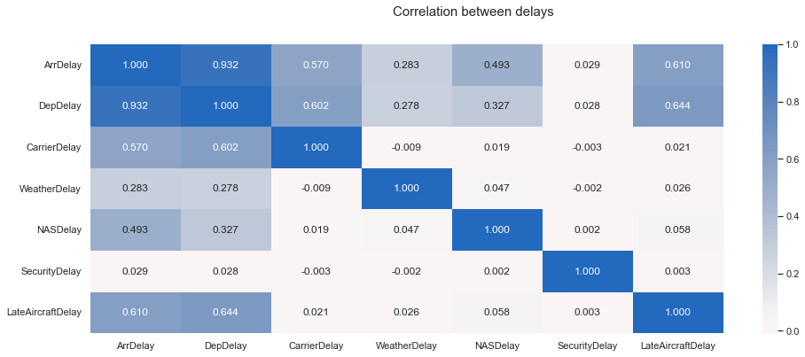